# 8일차

```python
import pandas as pd

# 출처: https://community.ibm.com/accelerators/?context=analytics&type=Data&product=Cognos%20Analytics
df = pd.read_csv('test3.csv')
print(df.shape)
df.head().T
```

```
(7043, 21)
```

|  | 0 | 1 | 2 | 3 | 4 |
| --- | --- | --- | --- | --- | --- |
| customerID | 7590-VHVEG | 5575-GNVDE | 3668-QPYBK | 7795-CFOCW | 9237-HQITU |
| gender | Female | Male | Male | Male | Female |
| SeniorCitizen | 0 | 0 | 0 | 0 | 0 |
| Partner | Yes | No | No | No | No |
| Dependents | No | No | No | No | No |
| tenure | 1 | 34 | 2 | 45 | 2 |
| PhoneService | No | Yes | Yes | No | Yes |
| MultipleLines | No phone service | No | No | No phone service | No |
| InternetService | DSL | DSL | DSL | DSL | Fiber optic |
| OnlineSecurity | No | Yes | Yes | Yes | No |
| OnlineBackup | Yes | No | Yes | No | No |
| DeviceProtection | No | Yes | No | Yes | No |
| TechSupport | No | No | No | Yes | No |
| StreamingTV | No | No | No | No | No |
| StreamingMovies | No | No | No | No | No |
| Contract | Month-to-month | One year | Month-to-month | One year | Month-to-month |
| PaperlessBilling | Yes | No | Yes | No | Yes |
| PaymentMethod | Electronic check | Mailed check | Mailed check | Bank transfer (automatic) | Electronic check |
| MonthlyCharges | 29.85 | 56.95 | 53.85 | 42.3 | 70.7 |
| TotalCharges | 29.85 | 1889.5 | 108.15 | 1840.75 | 151.65 |
| Churn | No | No | Yes | No | Yes |

```python
df.describe()
```

|  | SeniorCitizen | tenure | MonthlyCharges |
| --- | --- | --- | --- |
| count | 7043.000000 | 7043.000000 | 7043.000000 |
| mean | 0.162147 | 32.371149 | 64.761692 |
| std | 0.368612 | 24.559481 | 30.090047 |
| min | 0.000000 | 0.000000 | 18.250000 |
| 25% | 0.000000 | 9.000000 | 35.500000 |
| 50% | 0.000000 | 29.000000 | 70.350000 |
| 75% | 0.000000 | 55.000000 | 89.850000 |
| max | 1.000000 | 72.000000 | 118.750000 |

```python
df.sort_values(by='TotalCharges')['TotalCharges'][936]
```

```
' '
```

```python
df.loc[df['TotalCharges'] == ' ']
```

|  | customerID | gender | SeniorCitizen | Partner | Dependents | tenure | PhoneService | MultipleLines | InternetService | OnlineSecurity | ... | DeviceProtection | TechSupport | StreamingTV | StreamingMovies | Contract | PaperlessBilling | PaymentMethod | MonthlyCharges | TotalCharges | Churn |
| --- | --- | --- | --- | --- | --- | --- | --- | --- | --- | --- | --- | --- | --- | --- | --- | --- | --- | --- | --- | --- | --- |
| 488 | 4472-LVYGI | Female | 0 | Yes | Yes | 0 | No | No phone service | DSL | Yes | ... | Yes | Yes | Yes | No | Two year | Yes | Bank transfer (automatic) | 52.55 |  | No |
| 753 | 3115-CZMZD | Male | 0 | No | Yes | 0 | Yes | No | No | No internet service | ... | No internet service | No internet service | No internet service | No internet service | Two year | No | Mailed check | 20.25 |  | No |
| 936 | 5709-LVOEQ | Female | 0 | Yes | Yes | 0 | Yes | No | DSL | Yes | ... | Yes | No | Yes | Yes | Two year | No | Mailed check | 80.85 |  | No |
| 1082 | 4367-NUYAO | Male | 0 | Yes | Yes | 0 | Yes | Yes | No | No internet service | ... | No internet service | No internet service | No internet service | No internet service | Two year | No | Mailed check | 25.75 |  | No |
| 1340 | 1371-DWPAZ | Female | 0 | Yes | Yes | 0 | No | No phone service | DSL | Yes | ... | Yes | Yes | Yes | No | Two year | No | Credit card (automatic) | 56.05 |  | No |
| 3331 | 7644-OMVMY | Male | 0 | Yes | Yes | 0 | Yes | No | No | No internet service | ... | No internet service | No internet service | No internet service | No internet service | Two year | No | Mailed check | 19.85 |  | No |
| 3826 | 3213-VVOLG | Male | 0 | Yes | Yes | 0 | Yes | Yes | No | No internet service | ... | No internet service | No internet service | No internet service | No internet service | Two year | No | Mailed check | 25.35 |  | No |
| 4380 | 2520-SGTTA | Female | 0 | Yes | Yes | 0 | Yes | No | No | No internet service | ... | No internet service | No internet service | No internet service | No internet service | Two year | No | Mailed check | 20.00 |  | No |
| 5218 | 2923-ARZLG | Male | 0 | Yes | Yes | 0 | Yes | No | No | No internet service | ... | No internet service | No internet service | No internet service | No internet service | One year | Yes | Mailed check | 19.70 |  | No |
| 6670 | 4075-WKNIU | Female | 0 | Yes | Yes | 0 | Yes | Yes | DSL | No | ... | Yes | Yes | Yes | No | Two year | No | Mailed check | 73.35 |  | No |
| 6754 | 2775-SEFEE | Male | 0 | No | Yes | 0 | Yes | Yes | DSL | Yes | ... | No | Yes | No | No | Two year | Yes | Bank transfer (automatic) | 61.90 |  | No |

11 rows × 21 columns

```python
# Q1) SeniorCitizen의 값을 0과 1인데, 현재 Row에서는 모두 0이다.
#     그렇다면 Seniorcitizen의 값이 0인 Row는 TotalCharges가 빈 칸인 Row라고
#     볼 수 있을까? (SeniorCitizen은 대표성이 있는가?)

df['SeniorCitizen'].describe()

# A) SeniorCitizen 은 값이 0과 1인데, 75%까지 0이고, 1인 Row는 16%이므로 대표성이 없다.
```

```
count    7043.000000
mean        0.162147
std         0.368612
min         0.000000
25%         0.000000
50%         0.000000
75%         0.000000
max         1.000000
Name: SeniorCitizen, dtype: float64
```

```python
# Q2) 현재 Dependents는 대표성이 있나?

df.loc[df['Dependents'] == 'Yes']

# A) 대표성이 없다.
#    해당 조건에 맞는 Row 2110개로 전체 Row 중 약 2/7 이다.
#    따라서 Dependents가 Yes이기 때문에 TotalCharges가 빈 칸이라고 볼 수 없다.
#    즉, 대표성이 없다.
```

|  | customerID | gender | SeniorCitizen | Partner | Dependents | tenure | PhoneService | MultipleLines | InternetService | OnlineSecurity | ... | DeviceProtection | TechSupport | StreamingTV | StreamingMovies | Contract | PaperlessBilling | PaymentMethod | MonthlyCharges | TotalCharges | Churn |
| --- | --- | --- | --- | --- | --- | --- | --- | --- | --- | --- | --- | --- | --- | --- | --- | --- | --- | --- | --- | --- | --- |
| 6 | 1452-KIOVK | Male | 0 | No | Yes | 22 | Yes | Yes | Fiber optic | No | ... | No | No | Yes | No | Month-to-month | Yes | Credit card (automatic) | 89.10 | 1949.4 | No |
| 9 | 6388-TABGU | Male | 0 | No | Yes | 62 | Yes | No | DSL | Yes | ... | No | No | No | No | One year | No | Bank transfer (automatic) | 56.15 | 3487.95 | No |
| 10 | 9763-GRSKD | Male | 0 | Yes | Yes | 13 | Yes | No | DSL | Yes | ... | No | No | No | No | Month-to-month | Yes | Mailed check | 49.95 | 587.45 | No |
| 15 | 3655-SNQYZ | Female | 0 | Yes | Yes | 69 | Yes | Yes | Fiber optic | Yes | ... | Yes | Yes | Yes | Yes | Two year | No | Credit card (automatic) | 113.25 | 7895.15 | No |
| 17 | 9959-WOFKT | Male | 0 | No | Yes | 71 | Yes | Yes | Fiber optic | Yes | ... | Yes | No | Yes | Yes | Two year | No | Bank transfer (automatic) | 106.70 | 7382.25 | No |
| ... | ... | ... | ... | ... | ... | ... | ... | ... | ... | ... | ... | ... | ... | ... | ... | ... | ... | ... | ... | ... | ... |
| 7018 | 1122-JWTJW | Male | 0 | Yes | Yes | 1 | Yes | No | Fiber optic | No | ... | No | No | No | No | Month-to-month | Yes | Mailed check | 70.65 | 70.65 | Yes |
| 7020 | 9837-FWLCH | Male | 0 | Yes | Yes | 12 | Yes | No | No | No internet service | ... | No internet service | No internet service | No internet service | No internet service | Month-to-month | Yes | Electronic check | 19.20 | 239 | No |
| 7038 | 6840-RESVB | Male | 0 | Yes | Yes | 24 | Yes | Yes | DSL | Yes | ... | Yes | Yes | Yes | Yes | One year | Yes | Mailed check | 84.80 | 1990.5 | No |
| 7039 | 2234-XADUH | Female | 0 | Yes | Yes | 72 | Yes | Yes | Fiber optic | No | ... | Yes | No | Yes | Yes | One year | Yes | Credit card (automatic) | 103.20 | 7362.9 | No |
| 7040 | 4801-JZAZL | Female | 0 | Yes | Yes | 11 | No | No phone service | DSL | Yes | ... | No | No | No | No | Month-to-month | Yes | Electronic check | 29.60 | 346.45 | No |

2110 rows × 21 columns

```python
# Q3) tenure는 대표성이 있는가?

df.loc[df['tenure'] == 0]

# A) 1개월 미만인 고객은 총 납부금액이 없다.
```

|  | customerID | gender | SeniorCitizen | Partner | Dependents | tenure | PhoneService | MultipleLines | InternetService | OnlineSecurity | ... | DeviceProtection | TechSupport | StreamingTV | StreamingMovies | Contract | PaperlessBilling | PaymentMethod | MonthlyCharges | TotalCharges | Churn |
| --- | --- | --- | --- | --- | --- | --- | --- | --- | --- | --- | --- | --- | --- | --- | --- | --- | --- | --- | --- | --- | --- |
| 488 | 4472-LVYGI | Female | 0 | Yes | Yes | 0 | No | No phone service | DSL | Yes | ... | Yes | Yes | Yes | No | Two year | Yes | Bank transfer (automatic) | 52.55 |  | No |
| 753 | 3115-CZMZD | Male | 0 | No | Yes | 0 | Yes | No | No | No internet service | ... | No internet service | No internet service | No internet service | No internet service | Two year | No | Mailed check | 20.25 |  | No |
| 936 | 5709-LVOEQ | Female | 0 | Yes | Yes | 0 | Yes | No | DSL | Yes | ... | Yes | No | Yes | Yes | Two year | No | Mailed check | 80.85 |  | No |
| 1082 | 4367-NUYAO | Male | 0 | Yes | Yes | 0 | Yes | Yes | No | No internet service | ... | No internet service | No internet service | No internet service | No internet service | Two year | No | Mailed check | 25.75 |  | No |
| 1340 | 1371-DWPAZ | Female | 0 | Yes | Yes | 0 | No | No phone service | DSL | Yes | ... | Yes | Yes | Yes | No | Two year | No | Credit card (automatic) | 56.05 |  | No |
| 3331 | 7644-OMVMY | Male | 0 | Yes | Yes | 0 | Yes | No | No | No internet service | ... | No internet service | No internet service | No internet service | No internet service | Two year | No | Mailed check | 19.85 |  | No |
| 3826 | 3213-VVOLG | Male | 0 | Yes | Yes | 0 | Yes | Yes | No | No internet service | ... | No internet service | No internet service | No internet service | No internet service | Two year | No | Mailed check | 25.35 |  | No |
| 4380 | 2520-SGTTA | Female | 0 | Yes | Yes | 0 | Yes | No | No | No internet service | ... | No internet service | No internet service | No internet service | No internet service | Two year | No | Mailed check | 20.00 |  | No |
| 5218 | 2923-ARZLG | Male | 0 | Yes | Yes | 0 | Yes | No | No | No internet service | ... | No internet service | No internet service | No internet service | No internet service | One year | Yes | Mailed check | 19.70 |  | No |
| 6670 | 4075-WKNIU | Female | 0 | Yes | Yes | 0 | Yes | Yes | DSL | No | ... | Yes | Yes | Yes | No | Two year | No | Mailed check | 73.35 |  | No |
| 6754 | 2775-SEFEE | Male | 0 | No | Yes | 0 | Yes | Yes | DSL | Yes | ... | No | Yes | No | No | Two year | Yes | Bank transfer (automatic) | 61.90 |  | No |

11 rows × 21 columns

```python
df.loc[df['TotalCharges'] == ' ']['customerID'].values
```

```
array(['4472-LVYGI', '3115-CZMZD', '5709-LVOEQ', '4367-NUYAO',
       '1371-DWPAZ', '7644-OMVMY', '3213-VVOLG', '2520-SGTTA',
       '2923-ARZLG', '4075-WKNIU', '2775-SEFEE'], dtype=object)
```

```python
df.loc[df['tenure'] == 0]['customerID'].values
```

```
array(['4472-LVYGI', '3115-CZMZD', '5709-LVOEQ', '4367-NUYAO',
       '1371-DWPAZ', '7644-OMVMY', '3213-VVOLG', '2520-SGTTA',
       '2923-ARZLG', '4075-WKNIU', '2775-SEFEE'], dtype=object)
```

```python
tc_null = set(df.loc[df['TotalCharges'] == ' ']['customerID'].values)
te_null = set(df.loc[df['tenure'] == 0]['customerID'].values)

# difference, intersectiuon, union
print(len(tc_null.difference(te_null)))
print(len(te_null.difference(tc_null)))

# tenure가 0인 Row와 TotalCharges가 빈 칸인 Row는 정확히 같음
# 즉, 계약하고 1개월 미만인 고객들은 총 납무 금액이 모두 빈 칸으로 되어 있음
# 따라서 TotalCharges가 빈 칸인 Row는 모두 0으로 저장할 수 있음
```

```
0
0
```

```python
df.loc[df['tenure'] == 0, 'TotalCharges'] = 0

df['TotalCharges'] = df['TotalCharges'].apply(lambda x : float(x))
df.describe()
```

|  | SeniorCitizen | tenure | MonthlyCharges | TotalCharges |
| --- | --- | --- | --- | --- |
| count | 7043.000000 | 7043.000000 | 7043.000000 | 7043.000000 |
| mean | 0.162147 | 32.371149 | 64.761692 | 2279.734304 |
| std | 0.368612 | 24.559481 | 30.090047 | 2266.794470 |
| min | 0.000000 | 0.000000 | 18.250000 | 0.000000 |
| 25% | 0.000000 | 9.000000 | 35.500000 | 398.550000 |
| 50% | 0.000000 | 29.000000 | 70.350000 | 1394.550000 |
| 75% | 0.000000 | 55.000000 | 89.850000 | 3786.600000 |
| max | 1.000000 | 72.000000 | 118.750000 | 8684.800000 |

```python
# 현재 분석 방향성은 이탈률이 높은 그룹을 집중 관리하기 위함
set(df['Churn'])
```

```
{'No', 'Yes'}
```

```python
df['Churn_num'] = df['Churn'].map({'Yes':1, 'No':0})
df.describe()

# 고객 이탈의 여부가 26% 정도 -> 어떤 평가지표를 적용하는 것이 좋을까?
# 경우의 수가 한 쪽으로 치우쳐진 경우이므로 acc보다 prec이나 recall을 사용해야 함
```

|  | SeniorCitizen | tenure | MonthlyCharges | TotalCharges | Churn_num |
| --- | --- | --- | --- | --- | --- |
| count | 7043.000000 | 7043.000000 | 7043.000000 | 7043.000000 | 7043.000000 |
| mean | 0.162147 | 32.371149 | 64.761692 | 2279.734304 | 0.265370 |
| std | 0.368612 | 24.559481 | 30.090047 | 2266.794470 | 0.441561 |
| min | 0.000000 | 0.000000 | 18.250000 | 0.000000 | 0.000000 |
| 25% | 0.000000 | 9.000000 | 35.500000 | 398.550000 | 0.000000 |
| 50% | 0.000000 | 29.000000 | 70.350000 | 1394.550000 | 0.000000 |
| 75% | 0.000000 | 55.000000 | 89.850000 | 3786.600000 | 1.000000 |
| max | 1.000000 | 72.000000 | 118.750000 | 8684.800000 | 1.000000 |

## Data Exploration

- 방향성과 맞는 그래프 그리기: 고객 이탈과 가장 관련있는 요인이 무엇인지 확인

```python
import numpy as np

# 고객들의 계약 유지 기간에 따른 이탈률 확인
te_ch = df.groupby('tenure').agg({'Churn_num': np.mean}).reset_index()
te_ch
```

|  | tenure | Churn_num |
| --- | --- | --- |
| 0 | 0 | 0.000000 |
| 1 | 1 | 0.619902 |
| 2 | 2 | 0.516807 |
| 3 | 3 | 0.470000 |
| 4 | 4 | 0.471591 |
| ... | ... | ... |
| 68 | 68 | 0.090000 |
| 69 | 69 | 0.084211 |
| 70 | 70 | 0.092437 |
| 71 | 71 | 0.035294 |
| 72 | 72 | 0.016575 |

73 rows × 2 columns

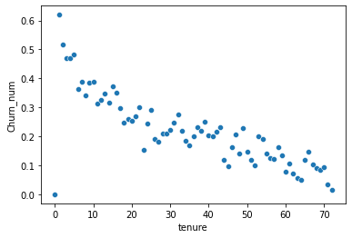

```python
import seaborn as sns

sns.scatterplot(data=te_ch, x='tenure', y='Churn_num')

# 계약기간이 길어질수록 이탈률이 낮아짐
```

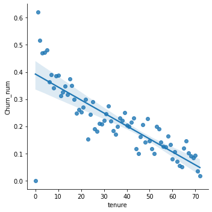

```python
sns.lmplot(data=te_ch, x='tenure', y='Churn_num')
```

```python
# 부양가족 유무 정보를 그래프 그릴 때 반영
hue = 'Dependents'
te_ch = df.groupby(['tenure', hue]).agg({'Churn_num': np.mean}).reset_index()
te_ch
```

|  | tenure | Dependents | Churn_num |
| --- | --- | --- | --- |
| 0 | 0 | Yes | 0.000000 |
| 1 | 1 | No | 0.632613 |
| 2 | 1 | Yes | 0.557692 |
| 3 | 2 | No | 0.538095 |
| 4 | 2 | Yes | 0.357143 |
| ... | ... | ... | ... |
| 140 | 70 | Yes | 0.063830 |
| 141 | 71 | No | 0.038095 |
| 142 | 71 | Yes | 0.030769 |
| 143 | 72 | No | 0.020000 |
| 144 | 72 | Yes | 0.012346 |

145 rows × 3 columns

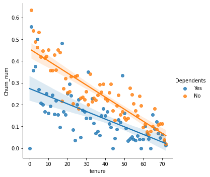

```python
sns.lmplot(data=te_ch, x='tenure', y='Churn_num', hue=hue)

# 계약기간이 길어짐에 따라 이탈률이 감소한다는 특징은 유지
# 부양가족이 있는 경우가 부양가족이 없는 경우보다 이탈률이 낮음
```

```python
df.describe(include='object')

# count: 개수
# unique: 서로 다른 데이터 개수
# top: 일반적인 값
# freq: 가장 일반적인 값의 빈도
```

|  | customerID | gender | Partner | Dependents | PhoneService | MultipleLines | InternetService | OnlineSecurity | OnlineBackup | DeviceProtection | TechSupport | StreamingTV | StreamingMovies | Contract | PaperlessBilling | PaymentMethod | Churn |
| --- | --- | --- | --- | --- | --- | --- | --- | --- | --- | --- | --- | --- | --- | --- | --- | --- | --- |
| count | 7043 | 7043 | 7043 | 7043 | 7043 | 7043 | 7043 | 7043 | 7043 | 7043 | 7043 | 7043 | 7043 | 7043 | 7043 | 7043 | 7043 |
| unique | 7043 | 2 | 2 | 2 | 2 | 3 | 3 | 3 | 3 | 3 | 3 | 3 | 3 | 3 | 2 | 4 | 2 |
| top | 7590-VHVEG | Male | No | No | Yes | No | Fiber optic | No | No | No | No | No | No | Month-to-month | Yes | Electronic check | No |
| freq | 1 | 3555 | 3641 | 4933 | 6361 | 3390 | 3096 | 3498 | 3088 | 3095 | 3473 | 2810 | 2785 | 3875 | 4171 | 2365 | 5174 |

```python
df.describe(include='object').columns
```

```
Index(['customerID', 'gender', 'Partner', 'Dependents', 'PhoneService',
       'MultipleLines', 'InternetService', 'OnlineSecurity', 'OnlineBackup',
       'DeviceProtection', 'TechSupport', 'StreamingTV', 'StreamingMovies',
       'Contract', 'PaperlessBilling', 'PaymentMethod', 'Churn'],
      dtype='object')
```

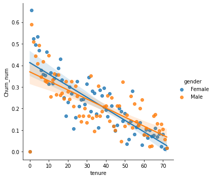

```python
hue = 'gender'
te_ch = df.groupby(['tenure', hue]).agg({'Churn_num': np.mean}).reset_index()
sns.lmplot(data=te_ch, x='tenure', y='Churn_num', hue=hue)

# 성별에 따른 차이가 발견되지 않음
```

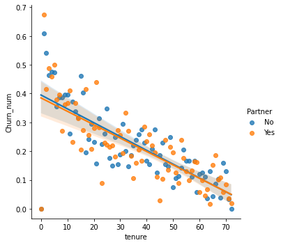

```python
hue = 'Partner'
te_ch = df.groupby(['tenure', hue]).agg({'Churn_num': np.mean}).reset_index()
sns.lmplot(data=te_ch, x='tenure', y='Churn_num', hue=hue)

# 동반자 여부에 따른 차이가 발견되지 않음
```

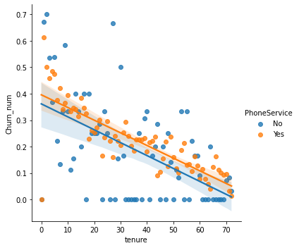

```python
hue = 'PhoneService'
te_ch = df.groupby(['tenure', hue]).agg({'Churn_num': np.mean}).reset_index()
sns.lmplot(data=te_ch, x='tenure', y='Churn_num', hue=hue)

# PhoneService를 사용하지 않으면 이탈률이 전체적으로 낮아지는 경향이 있지만,
# 이탈률이 0%인 경우가 많고, 편차도 큼
# 즉, 전화 사용 여부에 따른 차이가 발견되지 않음
```

```python
df.loc[df['tenure'] == 32]['PhoneService'].value_counts()

# 32개월동안 휴대폰 서비스를 사용하지 않는 사람은 4명
# 이 4명이 이탈하지 않으면 0%
```

```
Yes    65
No      4
Name: PhoneService, dtype: int64
```

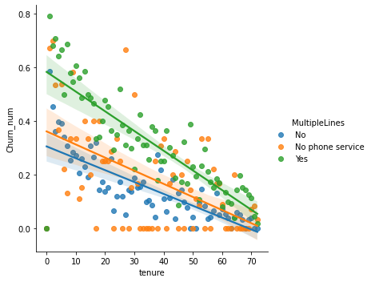

```python
hue = 'MultipleLines'
te_ch = df.groupby(['tenure', hue]).agg({'Churn_num': np.mean}).reset_index()
sns.lmplot(data=te_ch, x='tenure', y='Churn_num', hue=hue)

# 다중회선을 사용하면 이탈률이 높아지는 경향 확인
```

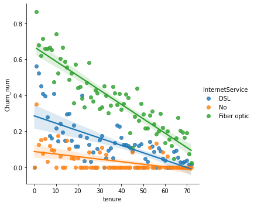

```python
hue = 'InternetService'
te_ch = df.groupby(['tenure', hue]).agg({'Churn_num': np.mean}).reset_index()
sns.lmplot(data=te_ch, x='tenure', y='Churn_num', hue=hue)

# 인터넷 속도가 증가할수록 이탈률이 높아지는 경향 확인
```

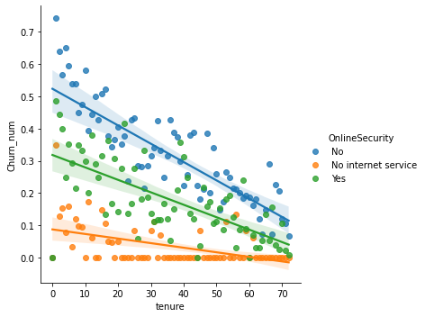

```python
hue = 'OnlineSecurity'
te_ch = df.groupby(['tenure', hue]).agg({'Churn_num': np.mean}).reset_index()
sns.lmplot(data=te_ch, x='tenure', y='Churn_num', hue=hue)

# 보안 서비스를 이용하면 이탈률이 낮아지는 경향 확인
```

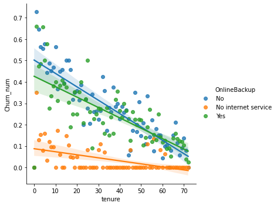

```python
hue = 'OnlineBackup'
te_ch = df.groupby(['tenure', hue]).agg({'Churn_num': np.mean}).reset_index()
sns.lmplot(data=te_ch, x='tenure', y='Churn_num', hue=hue)

# 백업 서비스 이용여부에 따른 이탈률의 차이가 없음
```

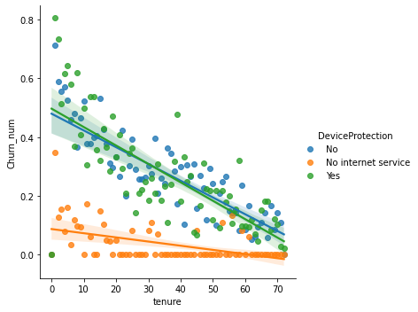

```python
hue = 'DeviceProtection'
te_ch = df.groupby(['tenure', hue]).agg({'Churn_num': np.mean}).reset_index()
sns.lmplot(data=te_ch, x='tenure', y='Churn_num', hue=hue)

# 기기 보호 서비스 이용여부에 따른 이탈률의 차이가 없음
```

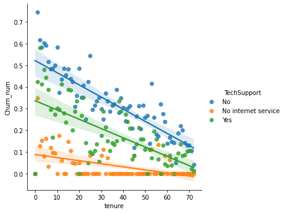

```python
hue = 'TechSupport'
te_ch = df.groupby(['tenure', hue]).agg({'Churn_num': np.mean}).reset_index()
sns.lmplot(data=te_ch, x='tenure', y='Churn_num', hue=hue)

# 기술 지원 서비스를 이용하면 이탈률이 낮아지는 경향 발견
```

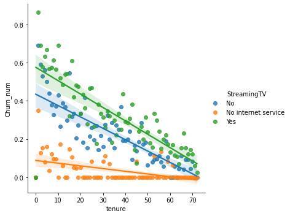

```python
hue = 'StreamingTV'
te_ch = df.groupby(['tenure', hue]).agg({'Churn_num': np.mean}).reset_index()
sns.lmplot(data=te_ch, x='tenure', y='Churn_num', hue=hue)

# 스트리밍 TV 서비스를 이용하면 이탈률이 높아지는 경향 발견
```

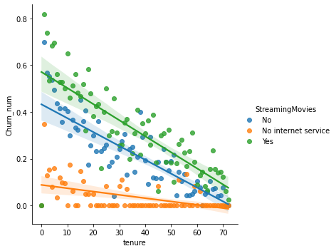

```python
hue = 'StreamingMovies'
te_ch = df.groupby(['tenure', hue]).agg({'Churn_num': np.mean}).reset_index()
sns.lmplot(data=te_ch, x='tenure', y='Churn_num', hue=hue)

# 스트리밍 영화 서비스를 이용하면 이탈률이 높아지는 경향 발견
```

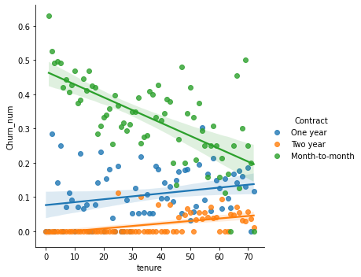

```python
hue = 'Contract' # 결제 갱신주기
te_ch = df.groupby(['tenure', hue]).agg({'Churn_num': np.mean}).reset_index()
sns.lmplot(data=te_ch, x='tenure', y='Churn_num', hue=hue)

# 계약기간이 늘어남에 따라 이탈률이 감소한다는 특징이 유지되지 않음
# 2년 계약의 경우에 tenure가 24까지 0%이고 이후에 취소함
# 1년 계약에서는 나타나지 않음
# 결제 갱신주기가 짧을수록 이탈률이 높아지는 경향이 발견
```

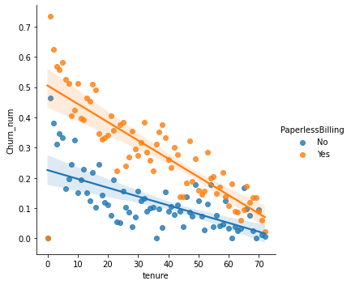

```python
hue = 'PaperlessBilling'
te_ch = df.groupby(['tenure', hue]).agg({'Churn_num': np.mean}).reset_index()
sns.lmplot(data=te_ch, x='tenure', y='Churn_num', hue=hue)

# 통지서가 paperless일 경우 이탈률이 더 높음
```

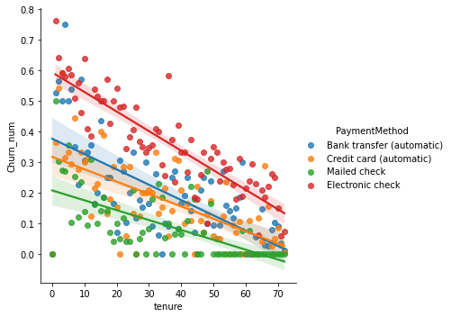

```python
hue = 'PaymentMethod'
te_ch = df.groupby(['tenure', hue]).agg({'Churn_num': np.mean}).reset_index()
sns.lmplot(data=te_ch, x='tenure', y='Churn_num', hue=hue)

# 계좌이체와 카드 결제는 유사한 특징(자동결제)이 있음
# 지로통지서는 이탈률이 가장 낮음
# 전자통지서는 이탈률이 가장 높음
```

#### 공통 특징

- 계약기간이 늘어남에 따라 이탈률이 감소
- 성별이나 독신여부에 따른 차이는 없음
- 전화 사용여부, 백업, 기기보호 서비스 이용여부에 따른 이탈여부 차이는 없음

#### 고객정보 기반

- 부양가족이 있는 경우에 부양가족이 없는 경우보다 이탈률이 낮음

#### 서비스 종류 기반

- 인터넷 속도가 증가할수록(돈을 더 낼수록) 이탈률이 높아짐
- 다중회선, 스트리밍 TV와 영화를 사용하면(돈을 더 낼수록) 이탈률이 높아짐
- 보안과 기술지원 서비스를 이용하지 않으면(돈을 안 낼수록) 이탈률이 높아짐

#### 계약 정보 기반

- 계약기간이 늘어남에 따라 이탈률이 감소한다는 특징이 유지되지 않음
- 결제 갱신주기가 짧을수록 이탈률이 높아짐
- 통지서가 paperless일 경우 이탈률이 높아짐
- 지로통지서는 이탈률이 가장 낮음
- 전자통지서는 이탈률이 가장 높음
- 지불 방식의 발전 순서대로 이탈률이 높아짐

## Data Preparation

- 이상치 판별
- scaling
- 경우의 수 Column 처리
- 교차검증

## 이상치(Outlier)

- 기준을 정해서 기준선 밖에 있으면 이상치 판단

**기준을 정하는 방법**

- 평균에서 n표준편차 이상 떨어진 것을 이상치라 판단 -> 신뢰할 수 없음(이상치가 엄청 큰 값이 들어있을 수 있음)
- ex) 평균으로부터 엄청 크거나 작은 값이 있는데 이에 대한 경우의 수가 적으면 평균과 표준편차의 의미가 퇴색됨
- ex) 애초에 평균을 구할 때부터 이상치가 있으면 평균을 구할 때 잘못된 평균이 구해짐

**IQR(Inter Quartile Range)**

- inter: a와 b 사이
- Quartile: 크기 순으로 정렬했을 때, 4분할하여 순서상 25% 등수와 75% 등수

```python
df.describe()
```

|  | SeniorCitizen | tenure | MonthlyCharges | TotalCharges | Churn_num |
| --- | --- | --- | --- | --- | --- |
| count | 7043.000000 | 7043.000000 | 7043.000000 | 7043.000000 | 7043.000000 |
| mean | 0.162147 | 32.371149 | 64.761692 | 2279.734304 | 0.265370 |
| std | 0.368612 | 24.559481 | 30.090047 | 2266.794470 | 0.441561 |
| min | 0.000000 | 0.000000 | 18.250000 | 0.000000 | 0.000000 |
| 25% | 0.000000 | 9.000000 | 35.500000 | 398.550000 | 0.000000 |
| 50% | 0.000000 | 29.000000 | 70.350000 | 1394.550000 | 0.000000 |
| 75% | 0.000000 | 55.000000 | 89.850000 | 3786.600000 | 1.000000 |
| max | 1.000000 | 72.000000 | 118.750000 | 8684.800000 | 1.000000 |

```python
tgt_col = 'TotalCharges'
desc = df.describe()[tgt_col]

iqr = 1.5 * (desc['75%'] - desc['25%']) # 1.5 IQR
upper_lim = desc['75%'] + iqr
lower_lim = desc['25%'] - iqr

df.loc[(df[tgt_col] > upper_lim) | (df[tgt_col] < lower_lim)]
```

|  | customerID | gender | SeniorCitizen | Partner | Dependents | tenure | PhoneService | MultipleLines | InternetService | OnlineSecurity | ... | TechSupport | StreamingTV | StreamingMovies | Contract | PaperlessBilling | PaymentMethod | MonthlyCharges | TotalCharges | Churn | Churn_num |
| --- | --- | --- | --- | --- | --- | --- | --- | --- | --- | --- | --- | --- | --- | --- | --- | --- | --- | --- | --- | --- | --- |

0 rows × 22 columns

```python
# Q) TotalCharges Column을 대상으로 평균으로부터
#    표준편차 2.5에 해당하는 값들의 합을 구하세요.
# A)
# 740692.15
```

## Scaling

- 변수의 범위를 조정하는 것

#### 언제 scaling을 할까?

1. 단위가 큰 Column이 단위가 작은 Column에 비해 학습 단계에 미치는 영향이 큰 경우 -> 이 영향을 최소화하기 위해 scaling 함
2. 그래프 그릴 때, 같은 축을 공유해 시각화하는 경우
3. 자릿수가 작아야 속도가 빠른 경우 ex) 이미지 DL

#### scaling 종류

- min-max: 최소값을 0으로, 최대값을 1로
- standard: 평균을 0으로, 표준편차를 1로
- robust: 중간값(median)을 0으로, IQR를 1로
- 이상치에 미치는 영향도: min-max > standard > robust

#### scaling 할 때 이상치를 고려해야 하는 이유

- 계산 과정상 이상치가 직접 반영되기 때문

```python
# a - a = 0
# a / a = 1
# 0 * ? = 0
# 0 / ? = 0

tgt_col = 'tenure'
# max(df[tgt_col])

# 최소값을 0으로 만들고
minus_min = df[tgt_col] - np.min(df[tgt_col])
minus_min
```

```
0        1
1       34
2        2
3       45
4        2
        ..
7038    24
7039    72
7040    11
7041     4
7042    66
Name: tenure, Length: 7043, dtype: int64
```

```python
# 최대값으로 일괄 나누기
scaled = minus_min / np.max(minus_min)
scaled
```

```
0       0.013889
1       0.472222
2       0.027778
3       0.625000
4       0.027778
          ...
7038    0.333333
7039    1.000000
7040    0.152778
7041    0.055556
7042    0.916667
Name: tenure, Length: 7043, dtype: float64
```

```python
df[tgt_col + '_scal'] = scaled
df.describe()
```

|  | SeniorCitizen | tenure | MonthlyCharges | TotalCharges | Churn_num | tenure_scal |
| --- | --- | --- | --- | --- | --- | --- |
| count | 7043.000000 | 7043.000000 | 7043.000000 | 7043.000000 | 7043.000000 | 7043.000000 |
| mean | 0.162147 | 32.371149 | 64.761692 | 2279.734304 | 0.265370 | 0.449599 |
| std | 0.368612 | 24.559481 | 30.090047 | 2266.794470 | 0.441561 | 0.341104 |
| min | 0.000000 | 0.000000 | 18.250000 | 0.000000 | 0.000000 | 0.000000 |
| 25% | 0.000000 | 9.000000 | 35.500000 | 398.550000 | 0.000000 | 0.125000 |
| 50% | 0.000000 | 29.000000 | 70.350000 | 1394.550000 | 0.000000 | 0.402778 |
| 75% | 0.000000 | 55.000000 | 89.850000 | 3786.600000 | 1.000000 | 0.763889 |
| max | 1.000000 | 72.000000 | 118.750000 | 8684.800000 | 1.000000 | 1.000000 |

```python
# standard scaling 예시

scal_cols = ['tenure']
tgt_col = scal_cols[0]
minus_min =  df[tgt_col] - np.mean(df[tgt_col]) # 평균으로 빼기
df[tgt_col + '_scal'] = minus_min / np.std(minus_min)  # 표준편차로 나누기
df.describe()

# std: 1
# mean: 0
```

|  | SeniorCitizen | tenure | MonthlyCharges | TotalCharges | Churn_num | tenure_scal |
| --- | --- | --- | --- | --- | --- | --- |
| count | 7043.000000 | 7043.000000 | 7043.000000 | 7043.000000 | 7043.000000 | 7.043000e+03 |
| mean | 0.162147 | 32.371149 | 64.761692 | 2279.734304 | 0.265370 | -4.066982e-17 |
| std | 0.368612 | 24.559481 | 30.090047 | 2266.794470 | 0.441561 | 1.000071e+00 |
| min | 0.000000 | 0.000000 | 18.250000 | 0.000000 | 0.000000 | -1.318165e+00 |
| 25% | 0.000000 | 9.000000 | 35.500000 | 398.550000 | 0.000000 | -9.516817e-01 |
| 50% | 0.000000 | 29.000000 | 70.350000 | 1394.550000 | 0.000000 | -1.372744e-01 |
| 75% | 0.000000 | 55.000000 | 89.850000 | 3786.600000 | 1.000000 | 9.214551e-01 |
| max | 1.000000 | 72.000000 | 118.750000 | 8684.800000 | 1.000000 | 1.613701e+00 |

## 경우의 수 column 변환 과정

- yes-no 인 경우, 1-0으로 변환
- 기준을 정했을 때 정도의 차이 발생한다면 이를 데이터에 반영

```python
df.head().T
```

|  | 0 | 1 | 2 | 3 | 4 |
| --- | --- | --- | --- | --- | --- |
| customerID | 7590-VHVEG | 5575-GNVDE | 3668-QPYBK | 7795-CFOCW | 9237-HQITU |
| gender | Female | Male | Male | Male | Female |
| SeniorCitizen | 0 | 0 | 0 | 0 | 0 |
| Partner | Yes | No | No | No | No |
| Dependents | No | No | No | No | No |
| tenure | 1 | 34 | 2 | 45 | 2 |
| PhoneService | No | Yes | Yes | No | Yes |
| MultipleLines | No phone service | No | No | No phone service | No |
| InternetService | DSL | DSL | DSL | DSL | Fiber optic |
| OnlineSecurity | No | Yes | Yes | Yes | No |
| OnlineBackup | Yes | No | Yes | No | No |
| DeviceProtection | No | Yes | No | Yes | No |
| TechSupport | No | No | No | Yes | No |
| StreamingTV | No | No | No | No | No |
| StreamingMovies | No | No | No | No | No |
| Contract | Month-to-month | One year | Month-to-month | One year | Month-to-month |
| PaperlessBilling | Yes | No | Yes | No | Yes |
| PaymentMethod | Electronic check | Mailed check | Mailed check | Bank transfer (automatic) | Electronic check |
| MonthlyCharges | 29.85 | 56.95 | 53.85 | 42.3 | 70.7 |
| TotalCharges | 29.85 | 1889.5 | 108.15 | 1840.75 | 151.65 |
| Churn | No | No | Yes | No | Yes |
| Churn_num | 0 | 0 | 1 | 0 | 1 |
| tenure_scal | -1.277445 | 0.066327 | -1.236724 | 0.514251 | -1.236724 |

```python
yes_no_cols = ['Partner', 'Dependents', 'PhoneService', 'PaperlessBilling']
for tgt in yes_no_cols:
    mapper = {'No':0, 'Yes':1}
    df[tgt+ '_num'] = df[tgt].map(mapper)
df.head()
```

|  | customerID | gender | SeniorCitizen | Partner | Dependents | tenure | PhoneService | MultipleLines | InternetService | OnlineSecurity | ... | PaymentMethod | MonthlyCharges | TotalCharges | Churn | Churn_num | tenure_scal | Partner_num | Dependents_num | PhoneService_num | PaperlessBilling_num |
| --- | --- | --- | --- | --- | --- | --- | --- | --- | --- | --- | --- | --- | --- | --- | --- | --- | --- | --- | --- | --- | --- |
| 0 | 7590-VHVEG | Female | 0 | Yes | No | 1 | No | No phone service | DSL | No | ... | Electronic check | 29.85 | 29.85 | No | 0 | -1.277445 | 1 | 0 | 0 | 1 |
| 1 | 5575-GNVDE | Male | 0 | No | No | 34 | Yes | No | DSL | Yes | ... | Mailed check | 56.95 | 1889.50 | No | 0 | 0.066327 | 0 | 0 | 1 | 0 |
| 2 | 3668-QPYBK | Male | 0 | No | No | 2 | Yes | No | DSL | Yes | ... | Mailed check | 53.85 | 108.15 | Yes | 1 | -1.236724 | 0 | 0 | 1 | 1 |
| 3 | 7795-CFOCW | Male | 0 | No | No | 45 | No | No phone service | DSL | Yes | ... | Bank transfer (automatic) | 42.30 | 1840.75 | No | 0 | 0.514251 | 0 | 0 | 0 | 0 |
| 4 | 9237-HQITU | Female | 0 | No | No | 2 | Yes | No | Fiber optic | No | ... | Electronic check | 70.70 | 151.65 | Yes | 1 | -1.236724 | 0 | 0 | 1 | 1 |

5 rows × 27 columns

```python
set(df['InternetService'])
```

```
{'DSL', 'Fiber optic', 'No'}
```

```python
mapper = {'No': 0, 'DSL': 0.5, 'Fiber optic': 1}
df['InternetSpeed'] = df['InternetService'].map(mapper)
df.describe()
```

|  | SeniorCitizen | tenure | MonthlyCharges | TotalCharges | Churn_num | tenure_scal | Partner_num | Dependents_num | PhoneService_num | PaperlessBilling_num | InternetSpeed |
| --- | --- | --- | --- | --- | --- | --- | --- | --- | --- | --- | --- |
| count | 7043.000000 | 7043.000000 | 7043.000000 | 7043.000000 | 7043.000000 | 7.043000e+03 | 7043.000000 | 7043.000000 | 7043.000000 | 7043.000000 | 7043.000000 |
| mean | 0.162147 | 32.371149 | 64.761692 | 2279.734304 | 0.265370 | -4.066982e-17 | 0.483033 | 0.299588 | 0.903166 | 0.592219 | 0.611458 |
| std | 0.368612 | 24.559481 | 30.090047 | 2266.794470 | 0.441561 | 1.000071e+00 | 0.499748 | 0.458110 | 0.295752 | 0.491457 | 0.389438 |
| min | 0.000000 | 0.000000 | 18.250000 | 0.000000 | 0.000000 | -1.318165e+00 | 0.000000 | 0.000000 | 0.000000 | 0.000000 | 0.000000 |
| 25% | 0.000000 | 9.000000 | 35.500000 | 398.550000 | 0.000000 | -9.516817e-01 | 0.000000 | 0.000000 | 1.000000 | 0.000000 | 0.500000 |
| 50% | 0.000000 | 29.000000 | 70.350000 | 1394.550000 | 0.000000 | -1.372744e-01 | 0.000000 | 0.000000 | 1.000000 | 1.000000 | 0.500000 |
| 75% | 0.000000 | 55.000000 | 89.850000 | 3786.600000 | 1.000000 | 9.214551e-01 | 1.000000 | 1.000000 | 1.000000 | 1.000000 | 1.000000 |
| max | 1.000000 | 72.000000 | 118.750000 | 8684.800000 | 1.000000 | 1.613701e+00 | 1.000000 | 1.000000 | 1.000000 | 1.000000 | 1.000000 |

```python
df.describe().columns
```

```
Index(['SeniorCitizen', 'tenure', 'MonthlyCharges', 'TotalCharges',
       'Churn_num', 'tenure_scal', 'Partner_num', 'Dependents_num',
       'PhoneService_num', 'PaperlessBilling_num', 'InternetSpeed'],
      dtype='object')
```

```python
interested = ['SeniorCitizen', 'tenure', 'MonthlyCharges', 'TotalCharges',
       'Churn_num', 'tenure_scal', 'Partner_num', 'Dependents_num',
       'PhoneService_num', 'PaperlessBilling_num', 'InternetSpeed']

df[interested].to_csv('test3_modify.csv', index=False)
```

```python
df = pd.read_csv('test3_modify.csv')
df.columns
```

```
Index(['SeniorCitizen', 'tenure', 'MonthlyCharges', 'TotalCharges',
       'Churn_num', 'tenure_scal', 'Partner_num', 'Dependents_num',
       'PhoneService_num', 'PaperlessBilling_num', 'InternetSpeed'],
      dtype='object')
```

```python
# label
label = 'Churn_num'
features = ['SeniorCitizen', 'tenure_scal', 'Partner_num', 'Dependents_num',
       'PhoneService_num', 'PaperlessBilling_num', 'InternetSpeed']

X, y = df[features], df[label]
```

## 교차검증(Cross-Validation)

- train 셋이 너무 적으면 결과가 불안정함 -> 교차검증을 이용해 안정적인 검증 점수를 획득
- train 셋을 조금씩 떼어내 평가하는 과정을 여러 번 반복하고 점수를 평균하여 최종 검증 점수 획득

#### 교차검증 순서

1. Row의 순서 섞음
2. 데이터셋을 k등분(k-fold CV)
3. 첫 번째 데이터셋을 test로, 나머지를 train으로 사용
4. train 데이터로 학습하고, test 데이터로 채점해서 점수 확인
5. 두 번째 데이터셋을 test로 하고 3, 4 단계를 k번 반복
6. 평가지표 점수가 k개 생김 -> 이를 평균(cv-score)

```python
from sklearn.model_selection import cross_val_score as cvs
from sklearn.ensemble import RandomForestClassifier as rf

model = rf()

cvs(model, X, y, cv=5, scoring='precision')
```

```
array([0.55255255, 0.58139535, 0.54727794, 0.56302521, 0.56857143])
```

```python
np.mean(cvs(model, X, y, cv=5, scoring='precision'))
```

```
0.5625982935872778
```

## 군집 알고리즘

- 데이터를 여러 그룹으로 묶음(유사한 Row끼리 그룹화)

```python
from sklearn.cluster import KMeans

model = KMeans(n_clusters=4)
model.fit(X)
```

```
KMeans(n_clusters=4)
```

```python
model.labels_
```

```
array([0, 2, 0, ..., 0, 0, 3])
```

```python
df['cluster'] = model.labels_
df.head()
```

|  | SeniorCitizen | tenure | MonthlyCharges | TotalCharges | Churn_num | tenure_scal | Partner_num | Dependents_num | PhoneService_num | PaperlessBilling_num | InternetSpeed | cluster |
| --- | --- | --- | --- | --- | --- | --- | --- | --- | --- | --- | --- | --- |
| 0 | 0 | 1 | 29.85 | 29.85 | 0 | -1.277445 | 1 | 0 | 0 | 1 | 0.5 | 0 |
| 1 | 0 | 34 | 56.95 | 1889.50 | 0 | 0.066327 | 0 | 0 | 1 | 0 | 0.5 | 2 |
| 2 | 0 | 2 | 53.85 | 108.15 | 1 | -1.236724 | 0 | 0 | 1 | 1 | 0.5 | 0 |
| 3 | 0 | 45 | 42.30 | 1840.75 | 0 | 0.514251 | 0 | 0 | 0 | 0 | 0.5 | 3 |
| 4 | 0 | 2 | 70.70 | 151.65 | 1 | -1.236724 | 0 | 0 | 1 | 1 | 1.0 | 0 |

```python
# 각 그룹별 이탈률 확인
df.groupby('cluster').agg({label: np.mean})

# 이탈률의 값이 조금씩 다르지만 경향성은 비슷할 것임
```

| cluster | Churn_num |
| --- | --- |
| 0 | 0.478659 |
| 1 | 0.083736 |
| 2 | 0.236341 |
| 3 | 0.149787 |

```python
np.mean(df[label])

# 전체 고객 중 26% 정도 이탈하는데,
# 어떤 그룹은 평균 대비 2배 정도 이탈률이 높거나 낮다.
```

```
0.2653698707936959
```

```python
df.loc[df['cluster'] == 1][features].describe().T['mean'].reset_index()

# 이탈률이 가장 낮은 그룹의 특징 확인
```

|  | index | mean |
| --- | --- | --- |
| 0 | SeniorCitizen | 0.049919 |
| 1 | tenure_scal | 0.962438 |
| 2 | Partner_num | 0.921095 |
| 3 | Dependents_num | 1.000000 |
| 4 | PhoneService_num | 0.905797 |
| 5 | PaperlessBilling_num | 0.535427 |
| 6 | InternetSpeed | 0.532206 |

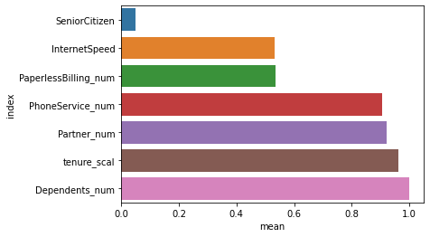

```python
for_plot = df.loc[df['cluster'] == 1][features].describe().T['mean'].reset_index()
sns.barplot(data=for_plot.sort_values(by='mean'), x='mean', y='index')

# 평균 대비 이탈률이 낮은 그룹의 특징
# Partner_num과 Dependents_num이 1에 가까움
# SeniorCitizen은 0에 가까움
```

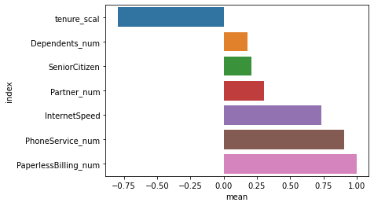

```python
for_plot = df.loc[df['cluster'] == 0][features].describe().T['mean'].reset_index()
sns.barplot(data=for_plot.sort_values(by='mean'), x='mean', y='index')
```

## 차원 축소(dimensionality reduction)

- 대표적인 차원 축소 알고리즘: 주성분분석(PCA)
- feature의 개수를 줄이는 것이지만 feature Selection과는 의미가 다름